# Football Salary Exploration

Kelly Rivera

# probability distribution

Data set: American Football: Analysis on the Salary of 5.5k Pro-Players

## Install & load libraries

```r
# Install tidyverse
#install.packages("tidyverse")

# load libraries
library(tidyverse)
library(ggplot2)
```

## Import Dataset CSV

```r
# Importing the csv file
football <- read_csv("football_salaries.csv") %>% filter(position %in% c("defensive-back", "offensive-line", "tight-end", "quarterback",
                                                                         "wide-receiver"),
                                                         age > 0,
                                                         age <= 50)
football
```

| position | player | team | age | total_value | avg_year | total_guaranteed | fully_guaranteed | free_agency |
| --- | --- | --- | --- | --- | --- | --- | --- | --- |
| tight-end | Jimmy Graham | Packers | 33 | 30000000 | 10000000 | 11000000 | 11000000 | 2021 UFA |
| tight-end | Travis Kelce | Chiefs | 30 | 46842000 | 9368400 | 20017000 | 10517000 | 2022 UFA |
| tight-end | Jordan Reed | Redskins | 29 | 46750000 | 9350000 | 22000000 | 14000000 | 2022 UFA |
| tight-end | Greg Olsen | Panthers | 34 | 17100000 | 8550000 | 12115000 | 12115000 | 2021 UFA |
| tight-end | Zach Ertz | Eagles | 29 | 42500000 | 8500000 | 20000000 | 13318527 | 2022 Void |
| tight-end | Delanie Walker | Titans | 35 | 17000000 | 8500000 | 12760000 | 10570000 | 2021 UFA |
| tight-end | Trey Burton | Bears | 28 | 32000000 | 8000000 | 22000000 | 18000000 | 2022 UFA |
| offensive-line | Trent Brown | Raiders | 26 | 66000000 | 16500000 | 36250000 | 36250000 | 2023 UFA |
| tight-end | Jared Cook | Saints | 32 | 15000000 | 7500000 | 8000000 | 8000000 | 2021 Void |
| tight-end | Kyle Rudolph | Vikings | 30 | 36500000 | 7300000 | 18500000 | 12640000 | 2020 UFA |

[output cut: 990 more lines]

```r
football$PlayerAge <- as.factor(football$age)
football
```

| position | player | team | age | total_value | avg_year | total_guaranteed | fully_guaranteed | free_agency | PlayerAge |
| --- | --- | --- | --- | --- | --- | --- | --- | --- | --- |
| tight-end | Jimmy Graham | Packers | 33 | 30000000 | 10000000 | 11000000 | 11000000 | 2021 UFA | 33 |
| tight-end | Travis Kelce | Chiefs | 30 | 46842000 | 9368400 | 20017000 | 10517000 | 2022 UFA | 30 |
| tight-end | Jordan Reed | Redskins | 29 | 46750000 | 9350000 | 22000000 | 14000000 | 2022 UFA | 29 |
| tight-end | Greg Olsen | Panthers | 34 | 17100000 | 8550000 | 12115000 | 12115000 | 2021 UFA | 34 |
| tight-end | Zach Ertz | Eagles | 29 | 42500000 | 8500000 | 20000000 | 13318527 | 2022 Void | 29 |
| tight-end | Delanie Walker | Titans | 35 | 17000000 | 8500000 | 12760000 | 10570000 | 2021 UFA | 35 |
| tight-end | Trey Burton | Bears | 28 | 32000000 | 8000000 | 22000000 | 18000000 | 2022 UFA | 28 |
| offensive-line | Trent Brown | Raiders | 26 | 66000000 | 16500000 | 36250000 | 36250000 | 2023 UFA | 26 |
| tight-end | Jared Cook | Saints | 32 | 15000000 | 7500000 | 8000000 | 8000000 | 2021 Void | 32 |
| tight-end | Kyle Rudolph | Vikings | 30 | 36500000 | 7300000 | 18500000 | 12640000 | 2020 UFA | 30 |

[output cut: 990 more lines]

## Data Exploration

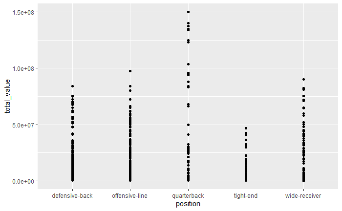

```r
ggplot(data = football, mapping = aes(x = position, y = total_value)) +
  geom_point()
```

```r
which.max(football$total_value)
```

```
[1] 120
```

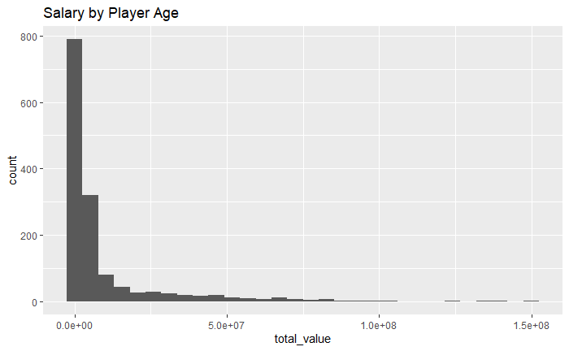

```r
ggplot(data = football, mapping = aes(x = total_value)) +
  geom_histogram() +
  labs(title = "Salary by Player Age")
```

## Histogram 1

1. What age is the most dominant of Pro-Football Players

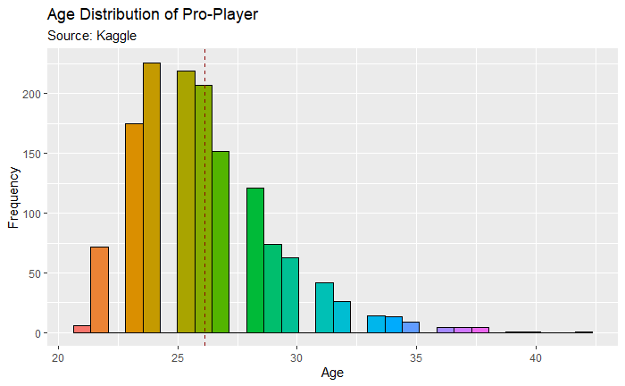

```r
ggplot(data = football, mapping = aes(x = age, fill = PlayerAge)) +
  geom_histogram(show.legend = FALSE, color = "black") +
  geom_vline(aes(xintercept = mean(age)), color = "red4", linetype = "dashed") +
  labs(title = "Age Distribution of Pro-Player",
       subtitle = "Source: Kaggle",
       x = "Age",
       y= "Frequency")
```

```r
cat("Distribution: Unimodal", '\n')
```

```
Distribution: Unimodal
```

```r
cat("Range: ", max(football$age) - min(football$age),'\n')
```

```
Range:  21
```

```r
cat("Mean: ", mean(football$age),'\n')
```

```
Mean:  26.12413
```

```r
cat("Median: ", median(football$age),'\n')
```

```
Median:  26
```

```r
cat("Standard Deviation: ", sd(football$age),'\n')
```

```
Standard Deviation:  2.96548
```

This graph is skewed right since the data is not symmetrical and the majority of data is toward the left. This visualization answers my initial question that the age of 23-24 is the most common age among pro-football players.

## Histogram 2

2. Of professional football players, what age group is generates the most money?

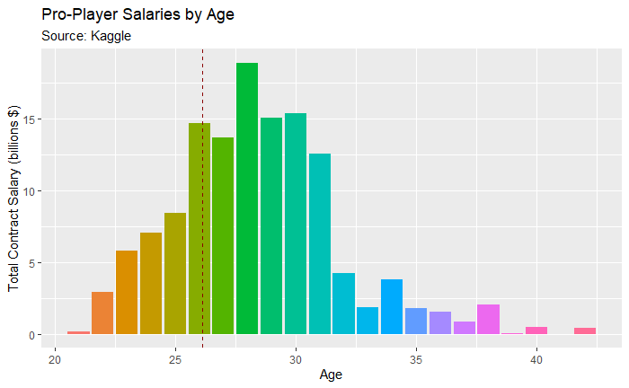

```r
ggplot(data = football, mapping = aes(x = age, y = total_value/100000000, fill = PlayerAge)) +
  geom_col(show.legend = FALSE) +
  geom_vline(aes(xintercept = mean(age)), color = "red4", linetype = "dashed") +
  labs(title = "Pro-Player Salaries by Age",
       subtitle = "Source: Kaggle",
       x = "Age",
       y= "Total Contract Salary (billions $)")
```

```r
cat("Distribution: Unimodal", '\n')
```

```
Distribution: Unimodal
```

```r
cat("Range: ", max(football$total_value) - min(football$total_value),'\n')
```

```
Range:  149895000
```

```r
cat("Mean: ", mean(football$total_value),'\n')
```

```
Mean:  9185152
```

```r
cat("Median: ", median(football$total_value),'\n')
```

```
Median:  2025000
```

```r
cat("Standard Deviation: ", sd(football$total_value),'\n')
```

```
Standard Deviation:  18160653
```

```r
# Taking the mean age for football player
youngsters <- filter(football, football$age >= 25, football$age <=27)
```

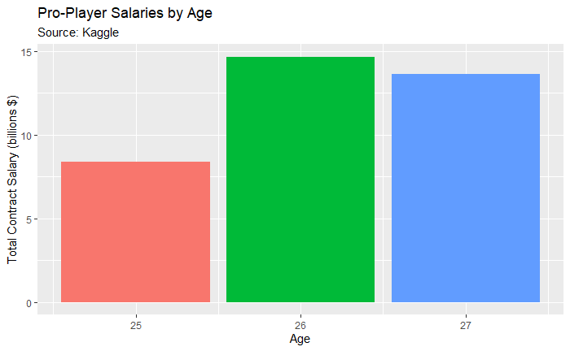

```r
ggplot(data = youngsters, mapping = aes(x = age, y = total_value/100000000, fill = PlayerAge)) +
  geom_col(show.legend = FALSE) +
  labs(title = "Pro-Player Salaries by Age",
       subtitle = "Source: Kaggle",
       x = "Age",
       y= "Total Contract Salary (billions $)")
```

```r
cat("Distribution: Unimodal", '\n')
```

```
Distribution: Unimodal
```

```r
cat("Range: ", max(youngsters$total_value) - min(youngsters$total_value),'\n')
```

```
Range:  89895000
```

```r
cat("Mean: ", mean(youngsters$total_value),'\n')
```

```
Mean:  6354439
```

```r
cat("Median: ", median(youngsters$total_value),'\n')
```

```
Median:  1717000
```

```r
cat("Standard Deviation: ", sd(youngsters$total_value),'\n')
```

```
Standard Deviation:  13406711
```

## Histogram 3

3. What annual amount is most common for Pro-Football Players to earn?

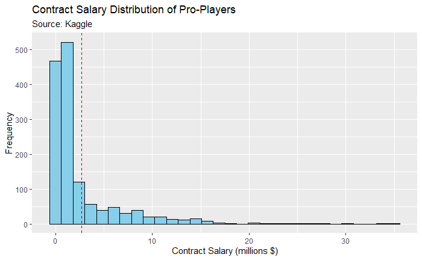

```r
ggplot(data = football, mapping = aes(x = avg_year/1000000)) +
  geom_histogram(color = "black", fill = "skyblue", show.legend = FALSE) +
  geom_vline(aes(xintercept = mean(avg_year/1000000)), color = "red4", linetype = "dashed") +
  labs(title = "Contract Salary Distribution of Pro-Players",
       subtitle = "Source: Kaggle",
       x = "Contract Salary (millions $)",
       y= "Frequency")
```

```r
cat("Distribution: Skewed Right", '\n')
```

```
Distribution: Skewed Right
```

```r
cat("Range: $", max(football$avg_year) - min(football$avg_year),'\n')
```

```
Range: $ 34980000
```

```r
cat("Mean: $", mean(football$avg_year),'\n')
```

```
Mean: $ 2668191
```

```r
cat("Median: $", median(football$avg_year),'\n')
```

```
Median: $ 729928
```

```r
cat("Standard Deviation: $", sd(football$avg_year),'\n')
```

```
Standard Deviation: $ 4208988
```

This graph is skewed right since the data is not symmetrical and a great majority of the data is toward the left side of the graph. This visualization answers my third question by showing that contract salaries between 1-2 million dollars are the most frequent among pro-football players.

## Histogram 4

4. What salary is most commonly guaranteed for a Pro-Football Player contract?

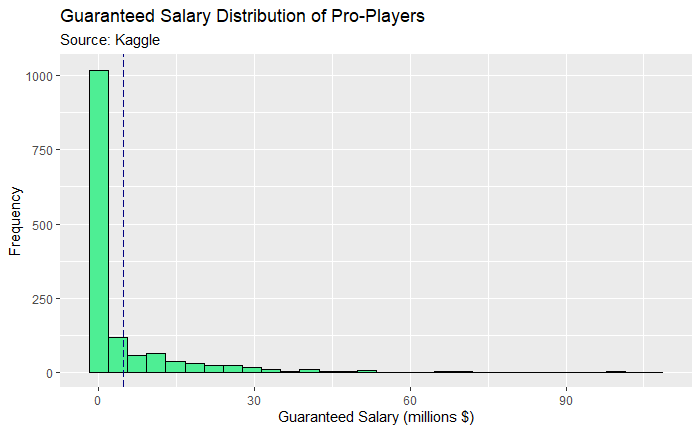

```r
ggplot(data = football, mapping = aes(x = total_guaranteed/1000000)) +
  geom_histogram(color = "black", fill = "seagreen2", show.legend = FALSE) +
  geom_vline(aes(xintercept = mean(total_guaranteed/1000000)), color = "navy", linetype = "longdash") +
  labs(title = "Guaranteed Salary Distribution of Pro-Players",
       subtitle = "Source: Kaggle",
       x = "Guaranteed Salary (millions $)",
       y= "Frequency")
```

```r
cat("Distribution: Skewed Right", '\n')
```

```
Distribution: Skewed Right
```

```r
cat("Range: $", max(football$total_guaranteed) - min(football$total_guaranteed),'\n')
```

```
Range: $ 1.07e+08
```

```r
cat("Mean: $", mean(football$total_guaranteed),'\n')
```

```
Mean: $ 4799878
```

```r
cat("Median: $", median(football$total_guaranteed),'\n')
```

```
Median: $ 118408
```

```r
cat("Standard Deviation: $", sd(football$total_guaranteed),'\n')
```

```
Standard Deviation: $ 11476088
```